# MEAPS & gravitaire : estimations à La Rochelle

Par

Affiliations

Maxime Parodi

[OFCE, Sciences Po Paris](http://www.ofce.fr)

Xavier Timbeau

[OFCE, Ecole Urbaine, Sciences Po Paris](http://www.ofce.fr)

Publié le

2 février 2024

Modifié le

10 mai 2024

Mots clés

modèle gravitaire, modèle radiatif, mobilités, glm, poisson, entropie relative

Résumé

L’estimation de modèles gravitaires est faite usuellement en utilisant les moindres carrés ordinaires. Nous montrons que la distribution des flux de navetteurs correspond mal à un modèle où l’erreur est log-normale. La représentation par une processus de Poisson, que l’on peut estimer par glm est plus apropriée. A partir de la log-vraisemblance, on remarque que l’estimation par glm est équivalente à la minimisation de l’entropie relative de Kullback-Leibler, ce qui permet l’estimation par minimisaiton non linéaire d’une famille plus grande de modèles, dont MEAPS. La discussion des effets fixes ou aléatoires permet de comprendre en quoi la modélisation respecte ou non les contraintes aux marges du problème. On montre que les modèles qui respectent ces marges peuvent être employés hors échantillon pour prédire les flux de navetteurs. enfin, en utilisant une information infracommunale on peut améliorer la qualité de l’ajustement de MEAPS et produire une intrapolation des flux à une résolution plus importante que celle des données de flux issues du recensement.  
12289 mots.

La confrontation d’un modèle aux données est une étape cruciale pour la compréhension de son fonctionnement et l’appréciation de sa pertinence. Nous explorons ici la capacité du modèle MEAPS à reproduire les flux de mobilités en le comparant au modèle gravitaire. La question est de savoir quel modèle est le mieux à même de reproduire les données observées de flux, à savoir les données MOBPRO tout en introduisant un minimum de paramètres, par souci de parcimonie et de généralité. De plus, cette capacité a expliquer les données doit reposer sur un fondement théorique le plus explicite possible, ce qui est la condition pour pouvoir interpréter les paramètres estimés.

La paramétrisation du modèle, le choix du modèle statistique, ou de la métrique à minimiser pour la détermination des paramètres sont autant de points à clarifier qui dépendent de la nature des données dont on dispose, mais aussi de ce qu’on pense être le processus qui les a générées. Cette discussion est cruciale puisqu’elle peut conduire à des estimations très différentes et qu’il faut expliciter ce qui en fait préférer l’une à l’autre. Elle est également importante pour diagnostiquer la qualité de la modélisation révélée par les données que l’on emploi et nourrir à la fois le processus de modélisation, et la compréhension des données.

Le point de départ est l’estimation d’un modèle gravitaire par les moindres carrés ordinaires (MCO). C’est habituellement ce qui est fait dans la littérature (Josselin *et al.* (2020) pour la région PACA en France par exemple, Lenormand, Bassolas et Ramasco (2016), Masucci *et al.* (2013) pour d’autres agglomérations). Mais cette approche mérite d’être approfondie.

## 1 Spécifications des modèles à estimer

Nous proposons d’utiliser l’entropie relative (ou critère d’information ou log vraisemblance d’une distribution multinomiale) comme fonction objectif à minimiser. Une régression par les moindres carrés ordinaires pondérée par les flux (c’est-à-dire la variable expliquée) donne un résultat plus proche de l’entropie relative que l’erreur quadratique moyenne non pondérée. Nous procédons ensuite à des estimations non-linéaires en utilisant principalement l’entropie relative comme fonction objectif (d’autres fonctions objectifs sont présentées pour comparer). Cette approche permet d’estimer des modèles gravitaires à simple contrainte (la constante $c$ de l’équation 1 n’est plus estimée et est remplacée par un vecteur $c_i$ qui assure le respect de la contrainte en ligne[^1]) et à double contrainte (à la fois la contrainte en ligne et en colonne sont respectées en utilisant par exemple la procédure de Furness). En utilisant la même procédure d’estimation non-linéaire avec comme fonction objectif l’entropie relative, nous estimons également *MEAPS* étendu afin de permettre une paramétrisation.

<sup>1</sup> INfrastructure for SPatial InfoRmation in Europe est depuis 2007 une directive pour la production de données spatialisées. Inspire définit une grille de carroyage et son système de projection harmonisée. C’est ce qui suit l’INSEE dans la diffusion des données carroyées. Voir https://inspire-geoportal.ec.europa.eu pour la définition de la grille et des jeux de données.

Nous déclinons enfin ces estimations en utilisant l’information infra-communale pour montrer que cette information peut accroître le pouvoir explicatif des modèles, en particulier de *MEAPS*. L’intuition est que l’information infra-communale permet une paramétrisation plus fine que sur la base de l’information communale. Bien que la variable expliquée (les flux) soit connue à l’échelle communale, l’injection d’une information infra-communale permet d’augmenter le pouvoir explicatif des modèles utilisés, particulièrement pour *MEAPS*.

### 1.1 Le modèle gravitaire standard : erreurs log-normales

L’estimation de modèle gravitaire est habituellement faite par une régression linéaire (Masucci *et al.*, 2013 ; Lenormand, Bassolas et Ramasco, 2016 ; Josselin *et al.*, 2020), par les moindres carrés ordinaires. Le modèle suivant est celui estimé, où les flux observés $f_{ij}$ sont la variable expliquée et les emplois $e$ repartis dans $J$ unités spatiales, les actifs $n$ répartis dans $I$ unités spatiales et la matrice de distance[^2] $[d_{ij}]$ sont les facteurs explicatifs :

<sup>2</sup> Nous avons pour simplifier l’exposition choisi une fonction « distance » particulière, paramétrée par $\delta$, appelée fonction puissance avec la forme $1/d^\delta$. Des alternatives sont possibles comme la fonction exponentielle, écrite comme $e^{-d/\delta}$, ou tout autre fonction de la distance, éventuellement paramétrée par plus d’un paramètre. Différentes métriques peuvent être utilisées pour analyser les distances. Cela peut être la distance à vol d’oiseau, la distance de parcours par les réseaux routiers ou le temps de parcours – qui permet d’intégrer les transports en commun. On peut également inclure un coût généralisé de transport, qui découle par exemple d’un modèle de choix discret et qui permet de prendre en compte des notions comme les préférences individuelles pour tel ou tel mode de transport (impliquant des vitesses et donc des temps différents) ou le confort ressenti par un mode de transport, que ce soit pendant le voyage ou par la sécurité qu’il procure dans la faible incertitude de sa réalisation. Nous utiliserons pour l’analyse communale la distance euclidienne à vol d’oiseau. Pour les analyses infracommunales, nous utiliserons des distances et des temps de parcours par les réseaux routiers ou de transport en commune suivant différents modes.

$$log(f_{ij}) = \alpha \times log(n_i) + \beta \times log(e_j) - \delta \times d_{ij} + c + \varepsilon_{ij}
\tag{1}$$

$$\varepsilon_{ij} \sim \mathcal{N}(0,\sigma^2)$$

Ainsi écrit le modèle gravitaire ne respecte la propriété de séparabilité que si les coefficients $\alpha$ et $\beta$ sont égaux à 1. Lorsque $\alpha$ est différent de 1, séparer un groupe de $n_i$ en deux sous groupes, pour lesquels les distances sont inchangées, conduit à projeter des flux dont la somme s’écarte du flux que l’on calcule pour les deux sous-groupes réunis. De façon symétrique, $\beta$ différent de 1 implique la même non séparabilité lors de la séparation d’un groupe $e_j$ en deux. Or cette propriété est nécessaire pour l’utilisation du modèle. Par exemple, la granularité de l’agrégation spatiale ne doit pas trop modifier les flux prévus surtout lorsque cette agrgégation est assez fine pour les distances relatives ne changent pas trop. La séparation des emplois en emplois par secteur, ou des individus suivant des caractéristiques socio-économiques ou suivant leurs préférences est un autre exemple de transformation à laquelle le modèle doit être robuste. Si on sépare les emplois en deux secteurs et que les comportements ne sont pas modifiés le long de cette séparation, il faut que les flux s’additionnent si on suit la cohérence de la modélisation.

Si l’estimation conduit à $\alpha\approx\beta\approx1$, la propriété de séparabilité sera (approximativement) respectée. Comme nous le verrons dans les estimations, et comme il ressort généralement de la littérature (par exemple Josselin *et al.*, 2020 pour la région PACA), les estimations, en règle générale, du modèle gravitaire par les MCO (i.e. avec des erreurs log-normales) donnent des $\alpha$ et des $\beta$ significativement inférieurs à 1. Le non-respect de cette propriété de séparabilité obère la portée du modèle et sa vraisemblance.

### 1.2 Quel processus générateur : gaussien ou poisson ?

Le modèle gravitaire log-linéaire estimé par les MCO suppose un bruit multiplicatif et un processus générateur dont les erreurs se compensent. Or les flux s’apparentent plus au résultat d’un comptage qu’au processus implicite du modèle MCO. Les flux ne sont donc plus à considérer comme des erreurs qui se compensent autour d’un modèle déterministe mais comme résultant d’une table de contingence et d’évènements independants mais dont on observe l’accumulation.

Plusieurs représentations sont possibles. Une première approche est de considérer le résultat comme celui d’un tirage avec remise de $n$ boules de différentes couleurs (la dimension $i$) et placées dans $j$ coupoles aléatoirement. C’est alors une loi multinomiale où chaque cellule de la table a une probabilité $\pi_{ij}$ et les fréquences sont $f_{ij} = n \times \pi_{ij}$ et où $n=\sum f_{ij}$.

Une alternative, très souvent employée en particulier dans les modèles linéaires généralisés, est de considérer la table de contingence comme produite par des processus de Poisson multivariés Agresti (2002).

Une des propriétés qui différencie ces deux grandes catégories de modèles (multinomial et Poisson versus log normal) se trouve au voisinage des valeurs faibles. Intuitivement, un processus de Poisson a pour variance l’espérance de ce processus. Pour un processus log-normal, la variance est une fonction de l’écart-type et de la moyenne du log du bruit et tend vers une valeur strictement positive lorsque la moyenne du log du bruit tend vers 0[^3]. Cette propriété implique que les erreurs relatives pour de petites valeurs dans une représentation log-normale ont une variance plus importante que celle d’un processus de Poisson[^4].

<sup>3</sup> Si $log(\varepsilon) \sim \mathcal N ( \mu, \sigma^2)$, alors $Var(\varepsilon) = (e^{\sigma^2}-1)e^{2\mu+\sigma^2}$.

<sup>4</sup> De façon plus générale, la famille `quasi,` dans l’estimation par `glm`, permet de spécifier un lien entre variance et moyenne et ainsi de définir des comportements au voisinage de 0 non pas constant (log linéaire), en lien avec la moyenne (Poisson) mais en carré de la moyenne (Bernouilli) ou en cube de la moyenne. Plus la dépendance est d’un ordre important, plus la variance tend rapidement vers 0.

Une autre façon d’apprécier la différence d’approche entre le modèle log-normal et la table de contingence est à travers la log-vraisemblance. A une constante (indépendante des paramètres à estimer) près la log-vraisemblance pour le modèle log-linéaire est l’erreur quadratique moyenne (*msre*), en notant $\hat f$ le flux prédit par le modèle et $f$ l’observation :

$$msre = \sum_i {({log(f}_{ij}) - log(\hat f_{ij}))^2 }
\tag{2}$$

Pour le processus de Poisson, en gardant les mêmes notations, la probabilité des observations connaissant le modèle est :

$$P(\hat f_{ij}= f_{ij}) = \frac{e^{-\hat f_{ij}}\times \hat f_{ij}^{f_{ij}}}{f_{ij}!} \tag{3}$$

La matrice de paramètres de Poisson $[\hat f_{ij}]$ peut alors être estimée à partir d’un modèle log-linéaire, qui peut être implémenté facilement par `glm`. C’est cette approche que Flowerdew et Aitkin (1982) applique à des flux de mobilité. On peut alors écrire le modèle gravitaire simplement :

$$log(\hat f_{ij}) = \alpha \times log(n_i) + \beta \times log(e_j) - \delta \times d_{ij} +c \tag{4}$$

On en déduit la log-vraisemblance, en notant $n=\sum f_{ij}$ et en approximant la factorielle par la formule de Stirling (Agresti, 2002) :

$$\mathcal{L} = -\hat n + \sum_{ij}{f_{ij} log(\hat f_{ij})} - \sum_{ij}{f_{ij}log(f_{ij})} \tag{5}$$

Dans cette expression, lorsque $n$ est connu (et donc $\hat n = n$), le processus de Poisson est une loi multinomiale la log-vraisemblance se simplifie par l’élimination de $\hat n$. Ainsi, la log-vraisemblance pour un processus multinomial est :

$$\mathcal L = \sum_{ij} f_{ij} log(\hat f_{ij} /n)
\tag{6}$$

L’expression de la log vraisemblance est alors (à une constante indépendante des paramètres près) égale au critère de gain d’information ou d’entropie relative (Kullback et Leibler, 1951) :

$$I(f_{ij}, \hat f_{ij}) = \frac 1 n \sum_i {f_{ij} \times (log(\hat f_{ij}) - log(f_{ij}))} \tag{7}$$

$$msre_w = \sum_i { f_{ij} \times (log(f_{ij}) - log(\hat f_{ij}))^2 } \tag{8}$$

Nous verrons qu’il existe, outre le carré, une différence entre ce critère et le critère d’entropie relative et qui a trait à la connaissance ou non de la somme totale des flux ou des sommes en ligne ou en colonne. Comme illustré dans la suite pour la Rochelle, le critère pondéré permet des résultats proches de ceux obtenus par `glm` et Poisson.

### 1.3 Contraintes en ligne et en colonne

La différence entre le modèle multinomial et le modèle de Poisson tient à la nature de l’information dont on dispose. Pour le modèle multinomial, le nombre total d’individus est fixé, alors qu’il est aléatoire dans le modèle de Poisson. Lorsqu’on passe, dans le modèle de Poisson, des comptes dans chaque case de la table de contingence aux probabilités, ces probabilités suivent une loi multinomiale. Si on connait non seulement le nombre d’individus, mais aussi les marges de la table de contingence (c’est-dire le nombre d’individus pour chaque ligne, ce qui revient à dire que chaque individu occupe un emploi et le nombre d’emplois pour chaque colonne, ce qui revient à dire que chaque emploi est occupé), alors la distribution sous-jacente est hypergéométrique multivariée[^5]. Elle est malheureusement utilisable que pour des dimensions très faibles, par exemple dans le test exact de Fisher (Agresti, 2002).

La formulation simple du modèle gravitaire n’est contrainte ni en ligne, ni en colonne. L’espérance de la somme $\sum_j \hat f_{ij}$ est différente de la $\sum_j {f_{ij}}$, généralement inférieure du fait de la convexité de la fonction $log$. Pour approcher ces contraintes, il faut introduire des paramètres supplémentaires, sous la forme d’effets fixes ou aléatoires. Les $I$ contraintes en ligne (appelées aussi simples contraintes, ou contraintes de production des flux) sont représentées en remplaçant la constante $c$ par un vecteur $a_i$ (de taille $I$) :

$$\begin{aligned}
log(f_{ij}) = & \alpha \times log(n_i) + \beta \times log(e_j) - \delta \times log(d_{ij}) \\ & + log(a_i) + \varepsilon_{ij}
\end{aligned}
\tag{9}$$

$$\varepsilon_{ij} \sim \mathcal{N}(0,\sigma^2)$$

On peut également le définir comme respectant explicitement les $I$ contraintes en ligne, et donc en tenant compte de la convexité de la fonction $log$ comme écrit dans l’équation 10. L’estimation en peut plus se faire directement par une régression linéaire, puisque le vecteur $a_i$ dépend à la fois de l’estimation de $\alpha$ et de celle de $\beta$. On peut les estimer par une procédure itérative ou une minimisation non linéaire, dont la fonction objectif pourra être la $msre$ par analogie avec les MCO, l’entropie relative par analogie avec un `glm` poisson ou la $msre_w$ pour approcher la précédente.

$$a_i = \frac{n_i}{\sum_j {\frac{n_i ^ \alpha \times e_j ^ \beta} { d_{ij}^{\delta} }}} = \frac{n_i ^ {1-\alpha}}{\sum_j { e_j ^ \beta / d_{ij}^{\delta} }}
\tag{10}$$

Que cela soit par un effet fixe ou aléatoire, dès que l’on introduit le vecteur $a_i$ dans le modèle, il n’est plus possible d’identifier $\alpha$ et on peut supposer pour $\alpha$ n’importe quelle valeur, les $a_i$ étant fonction de $\alpha$. Le respect de la propriété de séparabilité oblige cependant à choisir $\alpha=1$. Par l’expression de l’équation 10, le respect des contraintes en ligne induit nécessairement $\alpha=1$. En effet, $log(a_i)$ peut s’écrire comme la somme de $(1-\alpha)log(n_i)$ et d’un autre terme qui ne dépend que de $\beta$, $e_j$, $d_{ij}$ et $\delta$. L’équation initiale se réduit alors à un terme en $log(n_i)$. Dans le cas du respect des contraintes en ligne, l’élasticité des flux aux actifs est nécessairement unitaire.

Le respect des $J$ contraintes en colonne (appelées aussi contraintes d’attraction) est fait de manière similaire, en introduisant un vecteur $b_j$. Par le même raisonnement, on ne peut plus estimer $\beta$ et on le fixera à 1, pour respecter la contrainte de séparabilité. Le double respect des contraintes en ligne et en colonne peut se faire par la procédure de Furness (Dios Ortúzar et Willumsen, 2011 ; Griffith et Fischer, 2016) en définissant $a_i$ et $b_j$ comme suit :
$$a_i = \frac{n_i}{\sum_j {{b_j n_i ^ \alpha e_j ^ \beta} / { d_{ij}^{\delta} }}} = \frac{n_i ^ {1-\alpha}}{\sum_j { b_j e_j ^ \beta / d_{ij}^{\delta} }}
\tag{11}$$
$$b_j = \frac{e_j}{\sum_i { {a_i n_i ^ \alpha e_j ^ \beta} / { d_{ij}^{\delta} }}} = \frac{e_j ^ {1-\beta}}{\sum_i {a_i n_i ^ \alpha / d_{ij}^{\delta} }}
\tag{12}$$

Ce dernier modèle, par Furness, peut être estimé par un optimisation non linéaire sans grande difficulté, la procédure de Furness convergeant rapidement. En notant $\hat a_i = a_i/n_i^{1-\alpha}$ et $\hat b_j= b_j/e_j^{1-\beta}$ on a :

$$\hat a_i = \frac{1}{\sum_j { \hat b_j e_j/ d_{ij}^{\delta} }}
\tag{13}$$

$$\hat b_j = \frac{1}{\sum_i { \hat a_i n_i/ d_{ij}^{\delta} }}
\tag{14}$$

Ces deux dernières équations montrent que dans le cas de la double contrainte, les paramètres $\alpha$ et $\beta$ disparaissent et le modèle gravitaire se résume à l’équation suivante :

$$log(f_{ij}) = log(n_i) + log(e_j) - \delta \times d_{ij} + log(\hat a_i) + log(\hat b_j) + \varepsilon_{ij}
\tag{15}$$

L’élasticité de chaque flux $f_{ij}$ aux emplois ou aux résidents est nécessairement unitaire. Cette propriété introduit une différence subtile avec la formulation en effets fixes ou aléatoires dans laquelle les paramètres $\alpha$ et $\beta$ peuvent être fixés à n’importe quelle valeur, les $a_i$ et $b_j$ s’ajustant en fonction. Ceci signifie que dans la formulation effets fixes/aléatoires, le modèle est agnostique quant à la valeur des dérivées à l’augmentation de la masse « actif » ou de la masse « emploi ». L’estimation de $\delta$ est faite en déterminant pour chaque valeur de $\delta$ les flux, auxquels on applique Furness, et donc en calculant les $a_i(\delta)$ et $b_j(\delta)$. On calcule alors la fonction objectif $\mathcal{L}$ pour ces flux ($\mathcal{L}$ étant l’erreur quadratique moyenne ou les autres fonctions objectif) :

$$\hat \delta = \underset{\delta}{\mathrm{argmax}} \, \mathcal{L}(f_{ij}(\delta))
\tag{16}$$

Que l’on considère le modèle contraint par Furness ou le modèle augmenté d’effets fixes ou aléatoires, on est face à une difficulté d’interprétation. Indépendamment de leur mode de calcul, les coefficients $a_i$ et $b_j$ agissent comme des modificateurs des masses à l’origine ou à la destination. La partie déterministe du modèle gravitaire peu s’écrire comme l’équation 17 qui fait apparaître à quoi correspondent ces deux coefficients. Pour fonctionner le modèle gravitaire demande de « tricher » sur les masses, ce qui l’écarte de l’interprétation « gravitaire ».

$$\hat f_{ij} = f_0\frac{(a_i n_i)\times (b_j e_j)}{d_{ij}^\delta}
\tag{17}$$

La solution et l’interprétation proposées par Fotheringham (1983) sont plus intéressantes. Son point est de noter qu’il manque une variable au modèle gravitaire, décrivant le voisinage ou l’environnement de chaque leiu d’intérêt. Suivant son interprétation, les concentrations (des emplois réunis près les uns des autres) pourraient accroître l’attractivité, s’il y a un effet d’agglomération ou au contraire la diminuer s’il y a un effet de congestion ou de recherche de la solitude. Cependant, son approche ne résout pas la questions des contraintes en ligne et en colonne et fait simplement le pari que le problème sera moindre, une fois tenu compte de la concurrence entre opportunité.

**Encadré** 1**.** Déviance et entropie relative de Kullback-Leibler**

La déviance est permet de définir la qualité d’ajustement d’un modèle $M$ en généralisant la somme des erreurs au carré. Elle consiste à soustraire à la log vraisemblance du modèle saturé (i.e. avec autant de paramètres que d’observations) la log vraisemblance du modèle estimé, où $y$ sont les observations et $\hat y_M$ sont les prédictions à partir du modèle $M$ :

$$D(y, \hat y_M) = 2(log(P(y|M_{saturé}) - log(P(y|M))$$

La déviance n’est pas une distance, parce qu’elle n’est pas symétrique et qu’elle ne vérifie pas l’inégalité triangulaire.

On peut normer cette déviance en utilisant le modèle dit nul, c’est à dire avec un seul paramètre pour la constante. On a alors :

$$R^2_{dev} = 1 - D(y, \hat y_M)/D(y, \hat y _{null})$$

Pour un modèle linéaire, la déviance est la somme des erreurs au carré ( $\sum(y-\hat y)^2)$ ), et $R^2_{dev} = R^2$, ce qui justifie la notation.

Dans le cas de distributions ( $\sum p = 1$, $\sum q=1$ ), on peut définir un critère proche à partir de l’entropie relative de Kullback-Leibler (Kullback et Leibler, 1951). L’entropie relative est définie pour deux distributions de probabilités $p$ et $q$ comme suit dans le cas discret :

$$KL(p,q) = \sum_{i}p_i \times log(p_i/q_i)$$

Elle s’interprète dans le cadre de la théorie de l’information comme la quantité relative d’information supplémentaire nécessaire pour exprimer $q$ à partir de $p$. En suivant Colin Cameron et Windmeijer (1997) on peut construire une mesure de la qualité de l’ajustement $R_{KL}^2$ de la façon suivante, où $\hat{q}$ et $q_0$ sont deux distributions, respectivement celles estimée et de référence, que l’on compare à $p$ :

$$R_{KL}^2 = 1 - \frac{KL(p,\hat{q})}{KL(p, q_0)}$$

Si la distribution de référence est choisie comme une distribution uniforme, par analogie avec le calcul de la variance dans un $R^2$ habituel où l’on régresse sur une constante. On écrit :

$$\begin{aligned}
KL_u(p,q_{ref}) &{}= \sum_{i}p_i \times log(p_i/unif) \\&{}= \sum_i p_i \times log(p_i) - log(N)
\end{aligned}$$

Ceci n’est autre que l’entropie de la distribution $p$ à une constante près ($N$ est le nombre total de résidents actifs ou d’emplois). Le coefficient d’ajustement ainsi défini peut avoir pour des distributions très particulières des valeurs négatives ou supérieures à 1.

Si on connait les marges de la table de contingence (nombre d’actifs dans les origines $i$ et nombre d’emplois dans les destinations $j$), on peut utiliser comme référence non pas la distribution uniforme mais une distribution indépendante.

$$KL_i(p,q_{ref}) = \sum_{ij}p_{ij} \times [log(p_{ij}) -log( \frac{n_i \times e_j}{N^2})]$$

On construit à partir de ces deux références $R^2_{KLu}$ et $R^2_{KLi}$. Les 2 $R^2_{KL}$ ne nécessitent pas de connaître la vraisemblance et donc le modèle sous-jacent. Ils coïncident avec la déviance lorsque le modèle est une distribution multinomiale.

### 1.4 Extension de MEAPS avec des *odds-ratios*

Pour permettre une spécification plus fine, c’est-à-dire en ajoutant des paramètres, de *MEAPS*, nous introduisons pour chaque paire (*i*, *j*) un paramètre qui modifie la probabilité d’absorption de l’individu *i* par l’emploi *j*. On définit $c_{abs}$ comme la chance d’absorption, définie comme $c_{abs} = p_{abs}/(1-p_{abs})$ . Dans le *MEAPS* de référence, présenté plus haut, cette chance d’absorption est identique pour tous les emplois considérés par un individu et elle ne dépend que de la probabilité de fuite. Un moyen simple d’injecter de l’information dans le modèle consiste alors à modifier cette chance d’absorption selon les individus et les emplois qu’ils considèrent. Les modifications des probabilités d’absorption peuvent alors être paramétrées par des *odds-ratios* (des ratios de chances relatives) $\omicron_{ij}$ de telle manière que la nouvelle chance d’absorption de i en j soit égale à $\tilde{c}_{abs,ij} = \omicron_{ij} \times c_{abs}$. L’*odds-ratio* $\omicron_{ij}$ est un paramètre entre $0$ et $+\infty$ et *i* et *j* indexent les communes de départ et d’arrivée. La nouvelle probabilité d’absorption s’écrit alors à partir de la chance d’absorption de référence et de l’*odds-ratio* comme suit :

$$\tilde{p}_{abs,ij} = \frac{c_{abs} \times \omicron_{ij}} {1+c_{abs} \times \omicron_{ij}}$$

Une première stratégie de calage de *MEAPS* consiste à calculer autant d’*odds-ratios* qu’il y a de paires communes résidentes - communes d’emplois de manière à reproduire le plus fidèlement possible les flux agrégés de INSEE (2022a). Cette méthode conduit à saturer le modèle puisque l’on estime un nombre de paramètres proche ou égal au nombre de degrés de liberté imposé par INSEE (2022a). Cette stratégie d’apprentissage est analogue à ce qui se fait en *machine learning* du fait de la démultiplication du nombre de paramètres à estimer. La limite de cette approche est le sur-ajustement (*overfitting*) qu’elle induit. Celle-ci est habituellement corrigée en ajoutant une pénalité à la complexité du modèle au sein de la fonction d’optimisation. Cela peut également se faire par *pruning*, en éliminant *a posteriori* les paramètres dont la contribution à l’explication des données est inférieure à un seuil.

Les paramètres issues de cette approche contiennent une information qui peut ensuite être exploitée. Les *odds-ratios* s’interprètent alors relativement simplement : ceux qui sont supérieurs à 1 indiquent que le flux de mobilités professionnelles correspondant sont plus fréquents que ce que prévoit le modèle de référence ; et inversement pour les *odds-ratios* inférieurs à 1.

Une seconde stratégie est une estimation non linéaire. On choisit une structure pour les *odds-ratios*, en les paramétrisant par une des données disponibles (par exemple $\omicron_{ij} = O(d_{ij})$, la fonction $O$ étant paramétrisée par un ou plusieurs paramètres $\theta$. En définissant une fonction objectif (par exemple, l’entropie relative de Kullback Leibler), on peut estimer $\theta$ :

$$\hat \theta = \underset{\theta}{\mathrm{argmin}} \, \mathcal{L}(f^{meaps}_{ij}(O(d_{ij},\theta)))$$

## 2 Données au niveau communal

### 2.1 Mobilités professionnelles

La donnée principale que nous utilisons est issue du fichier détail du recensement. Nous partons de données individuelles, avec une information de localisation à la commune/arrondissement pour la résidence et l’emploi. Les données que nous employons sont issues du fichier détail des mobilités professionnelles de 2020[^6] accessible sur le [site de l’INSEE](https://www.insee.fr/fr/statistiques/7637844?sommaire=7637890&q=mobilites+professionnelles). Nous sélectionnons les individus appartenant à notre territoire d’intérêt : le SCoT de la Rochelle-Aunis pour l’estimation, une sélection d’autres SCoT pour le test, comme illustré sur la figure 1.

<sup>6</sup> 2020 a été marquée par le COVID. Outre les difficultés à suivre le plan de sondage, on peut estimer que l’analyse des flux de mobilité n’est pas perturbée au premier ordre. En effet, le recensement s’attache à identifier le lieu habituel de travail et de résidence. Les confinements ont probablement limité les changements d’emplois, mais le report d’une partie des relevés de terrain peut en partie compenser cet effet de fixation des emplois.

**Figure** 1**.** carte des SCoT

[figure not shown]

Le tableau 1 donne quelques statistiques descriptives pour les différents échantillons. La colonne *QQ plot* indique en particulier que les log des flux ne sont pas normalement distribués avec une masse importante en fin de distribution, ce qui est compatible avec une distribution de Poisson des flux.

**Tableau** 1**.** Description des échantillons d’estimation et de test

Nombre

distances (km)

f<sub>ij</sub>

log<sub>10</sub>(f<sub>ij</sub>)

QQ plot de log<sub>10</sub>(f<sub>ij</sub>)

actifs

flux

origines

destinations

moyenne<sup>1</sup>

écart type<sup>1</sup>

moyenne

écart type

part 1%

moyenne

écart type

La Rochelle-Aunis

86k

2195

72

261

11.6

11.9

39.3

203

33%

1.11

0.499

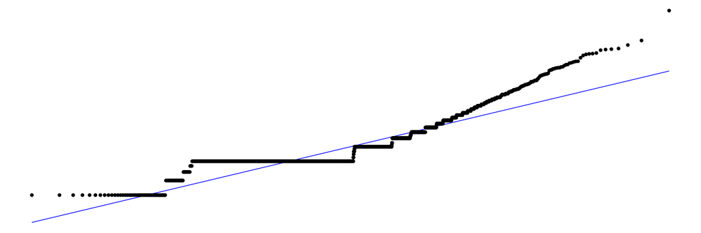

Métropole Aix-Marseille

699k

9775

107

1310

17.6

66.9

71.5

601

48%

1.00

0.670

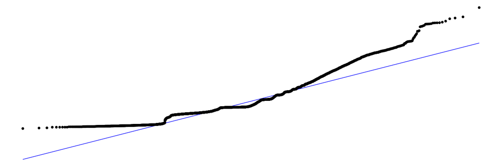

Pays Basque et Seignanx

132k

4015

166

729

21.5

84.6

32.8

240

45%

0.923

0.510

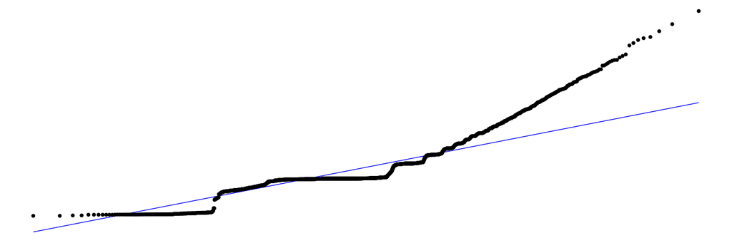

Niortais

50k

1286

40

404

15.0

45.0

38.7

489

53%

0.922

0.494

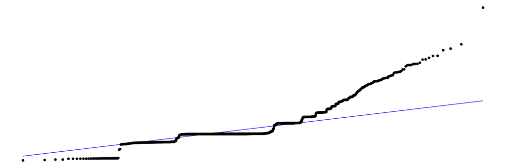

Caro (Rochefort)

23k

793

25

259

20.5

63.9

29.3

192

41%

0.939

0.471

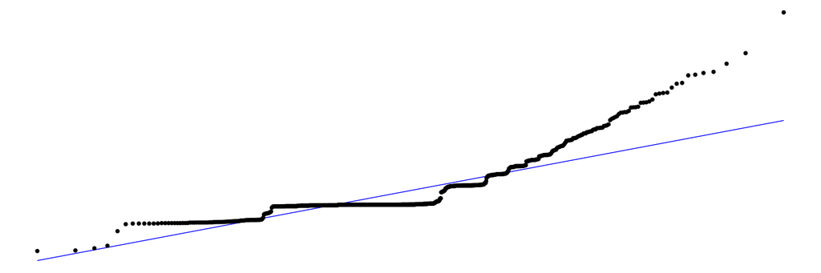

Quimperlé

21k

692

16

210

21.0

62.7

30.6

104

26%

1.03

0.510

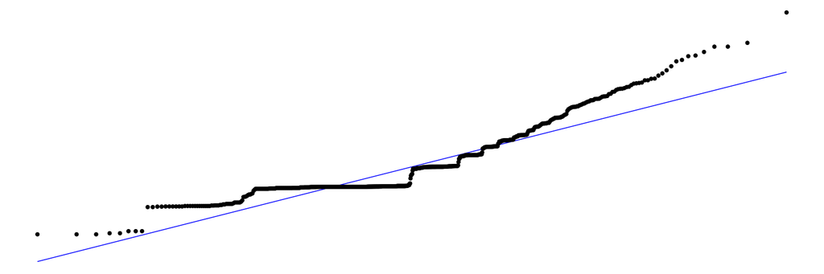

Pays des Olonnes

17k

326

5

227

19.0

71.0

52.7

537

66%

0.788

0.589

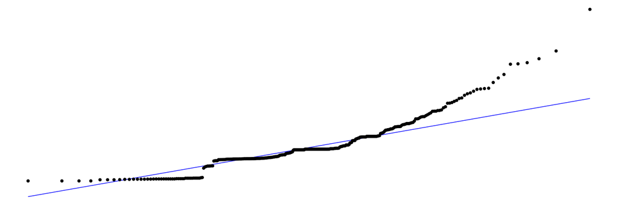

<sup>1</sup> pondéré par les flux

Afin de produire des intervalles de confiance, nous rééchantillonons les données d’estimation (*bootstrap*). Nous utilisons le fichier détail du recensement, en tirant avec remise les individus du territoire concerné, avec comme probabilité leur poids dans l’échantillon divisé par la somme des poids. Pour les individus ayant des poids proche de 5, lié au plan de sondage du recensement pour les communes de moins de 10 000 habitants, nous les décomposons en 5 individus de poids divisé par 5. Cela permet d’éviter des accumulations autour des multiples de 5 dans la distribution ré-échantillonnée.

Chaque échantillon « *boostrapé* » a le même nombre d’individus, avec la même distribution, et des individus peuvent être répétés, conformément au principe du *boostrap* (tirages avec remise).

Nous associons ensuite à chaque paire commune d’origine commune de destination une distance à vol d’oiseau euclidienne entre les centroïdes des communes. Pour les mouvements de la même commune vers la même commune, nous définissons la distance comme la moitié de la racine carrée de la surface. Ceci est une approximation de la valeur moyenne de la distance pour des points répartis aléatoirement sur un cercle de même surface. Dans la partie infra-communale, cette approximation est explicitement levée en localisant au carreau 200m résidents et emplois et en calculant les distances entre toutes les paires origine et destination. Toutes les distances sont exprimées en kilomètres.

Le fichier détail du recensement contient beaucoup de 0 implicites, c’est-à-dire des paires de communes pour lesquelles il n’y a aucun flux. Lorsque les communes sont très distantes, cela se comprend facilement. Mais lorsque l’on analyse un territoire (comme le SCoT de La Rochelle-Aunis), il existe des flux entre communes dont la distance est plus grande que d’autres qui ne sont pas reliées par un flux. Nous avons choisit de traiter comme 0 structurel ces absences de flux, même si l’hypothèse alternative qui voudrait modéliser ces flux presque nuls peut être défendue.

## 3 Ajustements « communaux » de modèles gravitaires et de *MEAPS*

### 3.1 Modèles gravitaires par MCO ou glm

Le tableau 2 donne les résultats d’estimations de différents modèles gravitaires non contraints (i.e $\alpha$ et $\beta$ sont estimés), contraints (i.e $\alpha=1$ et $\beta=1$), non pondérés (métrique standard) ou pondérés par les flux en niveau, estimés par `glm` avec les familles Poisson ou quasi-Poisson, avec effets fixes ou aléatoire ou sans. la forme estimée est l’équation 1 ou l’équation 4, en ajoutant les coefficients $a_i$ et f$b_j$ lorsque des effets fixes ou aléatoires sont ajoutés. Les régressions sont effectuées soit par `stat::lm`, soit par `stat::glm` dans R, soit par le package R `lme4` pour les effets fixes ou aléatoires. Le tableau présente différentes métriques (voir l’encadré 1 pour les définitions), ainsi que les degrés de liberté des résidus associés à chaque régression.

Dans l’ensemble des régressions, les paramètres estimés sont largement significatifs. La régression par les MCO non contrainte (ligne 1 du tableau 2) fait apparaître des coefficients $\alpha$ et $\beta$ inférieurs à 1, marquant une franche non séparabilité. Contraindre ces 2 paramètres dégrade fortement la qualité de l’estimation (ligne 2), sans pour autant modifier le coefficient associé à la distance. Josselin *et al.* (2020) estiment pour la région PACA des régressions proches de celle de la ligne 1, avec des $R^2$ comparables à ceux pour le périmètre de La Rochelle. Le coefficient de la distance qu’ils estiment est entre 0.9 et 1.4, soit nettement au-dessus de celui estimé pour La Rochelle. Ceci suggère que ce coefficient incorpore plus d’information que le simple effet de la distance et résume en partie l’information géographique sur les voisinages qui n’est introduite dans cette régression par aucune variable.

**Tableau** 2**.** Estimations communales, modèles gravitaires

|  |  | Modèle méthode | Modèle p | Modèle DL | Paramètres δ<sup>1</sup> | Paramètres α<sup>1</sup> | Paramètres β<sup>1</sup> | Métriques R<sup>2</sup><sub>KLu</sub><sup>2</sup> | Métriques R<sup>2</sup><sub>KLi</sub><sup>3</sup> | Métriques R<sup>2</sup><sub>dev</sub><sup>4</sup> |
| --- | --- | --- | --- | --- | --- | --- | --- | --- | --- | --- |
| 1 | Gravitaire<sup>5</sup> | mco | 4 | 2003 | 0.478*** *(0.0099)* (0.023) | 0.297*** *(0.014)* (0.02) | 0.399*** *(0.0035)* (0.01) | 62.3% | −42.9% | 44.6% |
| 2 | Gravitaire (contraint)<sup>6</sup> | mco | 2 | 2005 | 0.5*** *(0.011)* (0.041) | 1 (cont.) | 1 (cont.) | 79.0% | 20.5% | 6.3% |
| 3 | Gravitaire (FE)<sup>7</sup> | mco | 255 | 1752 | 0.974*** *(0.015)* (0.025) | 1 (cont.) | 1 (cont.) | 88.7% | 57.1% | 79.0% |
| 4 | Gravitaire (pondéré)<sup>5,8</sup> | mco | 4 | 2003 | 0.933*** *(0.0051)* (0.019) | 0.688*** *(0.012)* (0.02) | 0.638*** *(0.0022)* (0.0091) | 86.0% | 46.8% | 91.3% |
| 5 | Gravitaire (pondéré contraint)<sup>6,8</sup> | mco | 2 | 2005 | 0.647*** *(0.013)* (0.028) | 1 (cont.) | 1 (cont.) | 79.0% | 20.3% | 20.0% |
| 6 | Gravitaire (pondéré, FE)<sup>7,8</sup> | mco | 255 | 1752 | 1.32*** *(0.0078)* (0.018) | 1 (cont.) | 1 (cont.) | 94.1% | 77.6% | 89.4% |
| 7 | Gravitaire (poisson)<sup>5</sup> | glm poisson | 4 | 2003 | 0.93*** *(0.0054)* (0.0046) | 0.688*** *(0.014)* (0.0042) | 0.761*** *(0.0014)* (0.0021) | 87.1% | 51.2% | 87.1% |
| 8 | Gravitaire (poisson contraint)<sup>6</sup> | glm poisson | 2 | 2005 | 0.558*** *(0.0095)* (0.0042) | 1 (cont.) | 1 (cont.) | 79.1% | 20.7% | 20.4% |
| 9 | Gravitaire (poisson, FE)<sup>7</sup> | glm poisson | 255 | 1752 | 1.36*** *(0.0081)* (0.0062) | 1 (cont.) | 1 (cont.) | 94.5% | 79.4% | 79.3% |

<sup>1</sup> estimation du coefficient, entre paranthèse et en italique, erreur standard, entre paranthèse erreur standard calculée par boostrap (128 rééchantillonages avec remise)  
<sup>2</sup> Entropie relative de Kullback Leibler, normalisé par une distribution uniforme (voir encadré)  
<sup>3</sup> Entropie relative de Kullback Leibler, normalisé par une distribution indépendante (voir encadré  
<sup>4</sup> % de la déviance expliquée (voir encadré)  
<sup>5</sup> log(f<sub>ij</sub>)=αxlog(n<sub>ij</sub>)+βxlog(e<sub>ij</sub>)-δxlog(d<sub>ij</sub>)  
<sup>6</sup> log(f<sub>ij</sub>)=1xlog(n<sub>ij</sub>)+1xlog(emp<sub>ij</sub>)-δxlog(d<sub>ij</sub>)  
<sup>7</sup> log(f<sub>ij</sub>)=αxlog(act<sub>ij</sub>)+βxlog(e<sub>ij</sub>)-δxlog(d<sub>ij</sub>)+a<sub>i</sub>+b<sub>j</sub>  
<sup>8</sup> Régression pondérée par les flux

Comme évoqué plus haut, un des aspects problématique des régression par MCO sont le traitement des flux importants. Cet aspect est illustré par le figure 2 où sont représentés les flux observés versus les flux estimés. Les régressions par MCO peinent à estimer le flux le plus important (de la commune de La Rochelle vers La Rochelle). En utilisant la méthode des modèles linéaires généralisés (`glm`) avec des processus de Poisson résout cette question. La régression de la ligne 7 du tableau 2 illustre ce point. Les graphiques observés versus estimés permettent une appréciation graphique de l’amélioration de l’ajustement. Le biais pour les flux importants est plus faible, la dispersion générale également.

Les coefficients $\alpha$ et $\beta$ sont plus proches de 1, mais pour autant, la propriété de séparabilité n’est pas respectée comme l’illustre la régression contrainte de la ligne 8, pour laquelle la qualité d’ajustement est plus faible. Des estimations par des modèles « quasiPoisson », afin de prendre en compte une éventuelle sur-dispersion par rapport au modèle de Poisson produisent des résultats identiques à ceux par le modèle de Poisson.

Les régressions pondérées par les flux (lignes 4 à 6), dont la fonction objectif est proche du critère de gain d’information ou d’entropie relative, conduisent à des estimations très proches des modèles de des coefficients $\alpha$ et $\beta$ plus élevés. Ils restent néanmoins inférieurs à 1 et lorsqu’ils sont contraints à 1 (ligne 5), l’ajustement, tel que mesuré par le $R^2_{dev}$, se dégrade nettement. Le coefficient estimé pour la distance dépend assez largement de cette hypothèse, sauf pour l’estimation par les MCO.

**Figure** 2**.** Modèles gravitaires, Observés versus estimés

[figure not shown]

<sup>7</sup> Seuls les résultats des régressions à effet fixe (communes d’origine et communes de destination) sont reportés dans les tableaux ou des graphiques, les effets aléatoires donnent des résultats très proches. En revanche, pour les prédictions hors échantillon (*out of the bag*), nous utilisons les régressions à effets aléatoires, les effets fixes n’étant pas connus hors échantillon.

Dans le tableau 2, les écarts type des coefficients estimés sont reportés. Ils sont calculés de deux façons. La première ligne (en italique) est l’écart standard déduit du modèle. Par exemple, pour la ligne 1, il s’agit de l’écart standard pour chaque coefficient pour les MCO, c’est-à-dire en considérant que les résidus sont normaux. En dessous, l’écart type estimé par rééchantillonage (*boostrap*) est calculé directement sur l’échantillon des coefficients estimés sur les observations rééchantillonées. Pour les estimations par MCO, ces deux écarts type diffèrent fortement, ce qui remet en cause l’hypothèse de normalité des résidus et le modèle choisi. En revanche, pour les modèles estimés par `glm` et avec un processus générateur suivant une distribution de Poisson, on a bien proximité des écarts type par les deux méthodes.

Le tableau 3 présente les biais d’agrégation pour chacun des modèles estimés. Le biais d’agrégation du modèle gravitaire provient de ce que $e^{E(log(\hat f_{ij}))} \neq E(\hat f_{ij}) \neq E(f_{ij})$. Or le modèle gravitaire, dans sa forme log-linéaire, ne garantit que l’égalité des espérance des $log$. Il s’en suit, du fait de la convexité de la fonction $log$, un biais. La colonne « biais total » illustre l’ampleur de l’écart entre la somme des flux prédits et la somme des flux observés. Cet écart dépasse 60% pour le modèle gravitaire simple et 150% pour le modèle contraint. La pondération par les flux dans les régressions réduit le problème, mais seul la formulation en `glm` avec un processus de Poisson ramène ce biais à 0. En effet, par cette modélisation $E(\hat f_{ij}) = \hat f_{ij}$ ce qui assure la bonne agrégation des flux prédits.

**Tableau** 3**.** Modèles gravitaires, biais agrégé total, en ligne ou en colonne

|  |  | R<sup>2</sup><sub>dev</sub> | N<sub>o</sub> | N<sub>e</sub> | \|N<sub>o</sub>-N<sub>e</sub>\|/N<sub>o</sub> | Ligne<sup>1</sup> sse/N<sub>o</sub> | Ligne<sup>1</sup> sse(1%)/N<sub>o</sub><sup>3</sup> | colonne<sup>2</sup> sse/N<sub>o</sub> | colonne<sup>2</sup> sse(1%)/N<sub>o</sub><sup>3</sup> |
| --- | --- | --- | --- | --- | --- | --- | --- | --- | --- |
| 1 | Gravitaire | 45% | 84 953 | 31 778 | 63% | 40% | 26% | 40% | 40% |
| 2 | Gravitaire (contraint) | 6% | 84 953 | 214 622 | 153% | 100% | 74% | 100% | 99% |
| 3 | Gravitaire (FE) | 79% | 84 953 | 51 271 | 40% | 22% | 20% | 22% | 22% |
| 4 | Gravitaire (pondéré) | 91% | 84 953 | 114 610 | 35% | 13% | 3% | 13% | 8% |
| 5 | Gravitaire (pondéré contraint) | 20% | 84 953 | 133 313 | 57% | 47% | 40% | 47% | 46% |
| 6 | Gravitaire (pondéré, FE) | 89% | 84 953 | 96 414 | 13% | 2% | 2% | 2% | 1% |
| 7 | Gravitaire (poisson) | 87% | 84 953 | 84 968 | 0% | 9% | 3% | 9% | 7% |
| 8 | Gravitaire (poisson contraint) | 20% | 84 953 | 84 968 | 0% | 13% | 13% | 13% | 12% |
| 9 | Gravitaire (poisson, FE) | 79% | 84 953 | 84 968 | 0% | 0% | 0% | 0% | 0% |

<sup>1</sup> Le biais agrégé en ligne est (Σ<sub>i</sub>(Σ<sub>j</sub>f<sub>o</sub>-Σ<sub>j</sub>f<sub>e</sub>)<sup>2</sup>)/N<sub>o</sub>  
<sup>2</sup> Le biais agrégé en colonne est (Σ<sub>j</sub>(Σ<sub>i</sub>f<sub>o</sub>-Σ<sub>i</sub>f<sub>e</sub>)<sup>2</sup>)/N<sub>o</sub>  
<sup>3</sup> Biais agrégé pour les 1% plus grands flux observés relatif à N<sub>o</sub>

### 3.2 Estimations non linéaires

L’approche non linéaire permet d’estimer les paramètres de modèles plus complexes que ceux dont la formulation est linéaire. Dans les estimations non linéaires on cherche les paramètres qui minimisent une fonction objectif qui sera soit la somme pondéré des écarts entre les flux observés et les flux prédits (équation 8), soit l’entropie relative de Kullback Leibler (équation 6).

Par cette approche, on estime deux types de modèles gravitaires : un modèle contraint en ligne et un modèle doublement contraint en ligne et en colonne, spécifiés en suivant l’équation 15. Pour chaque valeur $\delta$ du paramètre de la distance, on calcule par itération les $\hat a_i$ ou les $\hat a_i$ et $\hat b_j$.

Pour *MEAPS*, on définit une structure des *odds-ratios,* par exemple $o_{ij} = O(d_{ij})$, et pour chaque valeur des paramètres, on calcule les flux par l’algorithme MEAPS. On cherche alors les paramètres qui minimisent l’entropie relative.

Que ce soit pour les modèles gravitaires ou MEAPS, les estimations sont répétées sur les observations rééchantillonées afin de pouvoir calculer une distribution de l’ensemble des statistiques et coefficients déterminés à chaque étape. Ceci permet ainsi de calculer des écarts type pour les coefficients estimés.

Les résultats de ces estimations pour les modèles gravitaires sont reportés dans le tableau 4 et dans le tableau 5 pour les différentes structures d’*odds-ratios* de *MEAPS*. La structure de ces tableaux est légèrement différente de ceux reportant les résultats par MCO ou `glm`, puisque, par exemple, on ne peut pas calculer la part de la déviance expliquée.

**Tableau** 4**.** Estimations non linéaires commune à commune, modèles gravitaires

|  |  | Modèle objectif | Modèle p | Modèle DL | Paramètres δ | Paramètres α | Paramètres β | Métriques R<sup>2</sup><sub>KLu</sub> | Métriques R<sup>2</sup><sub>KLi</sub> |
| --- | --- | --- | --- | --- | --- | --- | --- | --- | --- |
| 1 | Grav. (ligne)<sup>1</sup> | KL | 3 | 1932 | 1.16*** (0.0062) | 1 (cont.) | 0.784*** (0.0023) | 90.0% | 62.1% |
| 2 | Grav. (ligne)<sup>1</sup> | R<sup>2</sup><sub>w</sub> | 3 | 1932 | 1.05*** (0.0054) | 1 (cont.) | 0.685*** (0.0021) | 89.2% | 59.2% |
| 3 | Grav. (furness, l&c)<sup>2</sup> | KL | 1 | 1752 | 1.36*** (0.0072) | 1 (cont.) | 1 (cont.) | 94.5% | 79.3% |
| 4 | Grav. (furness, l&c)<sup>2</sup> | R<sup>2</sup><sub>w</sub> | 1 | 1752 | 1.34*** (0.0064) | 1 (cont.) | 1 (cont.) | 94.5% | 79.3% |

<sup>1</sup> log(f<sub>ij</sub>)=αxlog(n<sub>ij</sub>)+βxlog(e<sub>ij</sub>)-δxlog(d<sub>ij</sub>)+a<sub>i</sub> ; simple contrainte (en ligne)  
<sup>2</sup> log(f<sub>ij</sub>)=αxlog(n<sub>ij</sub>)+βxlog(e<sub>ij</sub>)-δxlog(d<sub>ij</sub>)+a<sub>i</sub>+b<sub>j</sub> ; double contrainte (lignes et colonnes)

L’utilisation de la métrique entropie relative de Kullback Leibler (*KL*) ou les erreurs au carré pondérées donnent des estimations proches. Le modèle gravitaire avec Furness donne les meilleurs résultats d’estimation et conduit à un paramètre de distance très proche de celui obtenu pour le modèle gravitaire à effet fixe estimé par `glm` et un processus de Poisson. Une nuance importante est que les $\hat a_i$ et $\hat b_j$ sont déterminés à partir des observations du nombre d’actifs et d’emploi par commune et donc peuvent être projetés hors échantillon, dès lors qu’on observe ces marges.

Les estimations de MEAPS sont uniquement réalisées à partir de la métrique *KL*. A titre de référence, les flux issus d’un MEAPS sans paramètre, et donc calibré uniquement à partir des marges en ligne et en colonne. La capacité prédictive de ce modèle (ligne 1) est moins bonne que des modèles à paramètre (lignes 2 à 5), mais du même ordre de grandeur que les modèles gravitaires sans effet fixe ou aléatoire (tableau 2). Une différence importante avec ces modèles est que à la fois la propriété de séparabilité et l’absence de biais d’agrégation (total, en ligne et en colonne) sont assurés par construction de MEAPS.

Différentes formes fonctionnelles sont envisagées :

Ligne 1 : le modèle est sans paramètre, uniquement ajusté sur les marges observées.

Ligne 2 : un paramètre pour tous les termes diagonaux, c’est-à-dire les flux allant d’une commune de résidence vers cette même commune pour l’emploi. Formellement, $\omicron_{i \neq j}=1$ et $\omicron_{ii} = o$. Le paramètre estimé est de 1.06 avec une erreur standard de 0.05.

Ligne 3 : Un paramètre pour toutes les flux de commune à même commune (diagonales) dont la densité est supérieure à un seuil et 1 partout ailleurs. Cette forme comprend donc deux paramètres et le seuil estimé est que l’*odds-ratio* spécifique est supérieur à 1 (1.17) pour un peu plus de 35% de la population (le seuil s’applique aux communes classées par densité croissante qui comptabilisent plus de 65% avec une erreur standard de 4 points. L’*odds-ratio* estimé est ainsi supérieur à celui du modèle de la ligne 2.

Lignes 5 et 6 : dans ces deux spécifications, les *odds-ratios* dépendent de la distance entre la commune d’origine et celle de destination, ce qui permet de combiner *MEAPS*, où c’est le rang pour chaque individu qui différencie les opportunités et une approche à partir de la distance. Ces spécifications ont deux paramètres et la dépendance à la distance est soit linéaire (ligne 6) soit exponentielle (ligne 5). Ces deux spécifications produisent les meilleurs ajustements.

**Tableau** 5**.** Estimations non linéaires commune à commune, MEAPS

|  |  | Modèle objectif | Modèle p | Modèle DL | Paramètres p<sub>1</sub> | Paramètres p<sub>2</sub> | Métriques R<sup>2</sup><sub>KLu</sub> | Métriques R<sup>2</sup><sub>KLi</sub> |
| --- | --- | --- | --- | --- | --- | --- | --- | --- |
| 1 | MEAPS 0p.<sup>1</sup> | - | 0 | 1753 | - | - | 82.0% | 51.6% |
| 2 | MEAPS (diag)<sup>2</sup> | KL | 1 | 1752 | 1.06*** (0.053) | - | 88.4% | 56.0% |
| 3 | MEAPS (diag&densité)<sup>3</sup> | KL | 2 | 1751 | 1.17*** (0.066) | 0.649*** (0.043) | 88.4% | 56.0% |
| 4 | MEAPS (diag&voisin)<sup>4</sup> | KL | 2 | 1751 | 1.06*** (0.052) | 0.962*** (0.057) | 88.4% | 56.0% |
| 5 | MEAPS (exp. decay)<sup>5</sup> | KL | 2 | 1751 | 3.37*** (0.077) | 0.0567*** (0.0021) | 91.4% | 67.4% |
| 6 | MEAPS (lin. decay)<sup>6</sup> | KL | 2 | 1751 | 14*** (0.33) | 2.75*** (0.0054) | 91.9% | 69.4% |

<sup>1</sup> o<sub>ij</sub>=1  
<sup>2</sup> o<sub>ii</sub>=p<sub>1</sub> ; o<sub>ij</sub>=1  
<sup>3</sup> o<sub>ii</sub>= [q(dens)>p<sub>2</sub>] p<sub>1</sub> ; [q(dens)<p<sub>2</sub>] 1  
<sup>4</sup> o<sub>ii</sub>=p<sub>1</sub> ; o<sub>iv(i)</sub>=p<sub>2</sub> ; o<sub>ij</sub>=1  
<sup>5</sup> o<sub>ij</sub>=1/d<sub>ij</sub><sup>p1</sup> + p<sub>2</sub>  
<sup>6</sup> o<sub>ij</sub>= [d<sub>ij</sub>>p<sub>2</sub>] 1 ; [d<sub>ij</sub><p<sub>2</sub>] p~1 - (p<sub>1</sub>-1)/p<sub>2</sub> d<sub>ij</sub>

L’examen des graphiques observés estimés confirme ce que les métriques indiquent figure 3. Il est à noter, qu’à part le modèle gravitaire contraint en ligne seulement, chacun des modèles estimé par la procédure non linéaire conduit à une prédiction proche de l’observé pour les plus grands flux. La différenciation se fait ensuite sur la capacité en prendre en compte les flux inférieurs à 1 000.

Rappelons que le modèle gravitaire modifié par Furness s’il possède une bonne capacité prédictive (voir également la performance hors échantillon, c’est au détriment de la portée explicative de ce modèle. MEAPS présente l’immense avantage de comprendre la mécanique à l’œuvre, celle qui conduit à ce que les contraintes soient respectées en ligne comme en colonne.

**Figure** 3**.** Estimations non linéaires, Observés versus estimés

[figure not shown]

### 3.3 Performance hors échantillon

Le test de modèles prédictifs hors échantillon est une discipline forte qui révèle de nombreuses propriétés des modèles. Le tableau 6 reporte la métrique $R^2_{KLi}$ du modèle estimé à La Rochelle-Aunis simulé pour les distances et les masses (actifs et emplois) observés sur d’autres SCoT. Sur la plupart des SCoT, les modèles gravitaires font moins bien qu’une distribution indépendante – qui utilise l’information sur les marges. Les modèles estimés par la procédure non linéaire font en revanche systématiquement mieux que la distribution indépendante et obtiennent des scores comparables à celui sur l’échantillon d’estimation. L’information des marges (le nombre d’actifs et d’emplois par commune) assure une bonne capacité prédictive, améliorée par la modélisation puisque la hiérarchie entre les modèles est conservée.

**Tableau** 6**.** Prédictions hors édhantillon (**out of the bag**)

|  | La Rochelle (estimation) | Métropole Aix-Marseille | Pays Basque et Seignanx | Niortais | Caro (Rochefort) | Quimperlé | Pays des Olonnes |
| --- | --- | --- | --- | --- | --- | --- | --- |
| Estimations linéaires |  |  |  |  |  |  |  |
| Gravitaire | −42.9% | 10.9% | 13.1% | −211.8% | −56.7% | −3.3% | −800.8% |
| Gravitaire (poisson) | 51.2% | 53.1% | 67.2% | 21.4% | 30.5% | 35.9% | −113.6% |
| Gravitaire (poisson, RE) | 79.4% | 49.0% | 33.3% | −166.5% | −190.4% | −9.9% | −207.9% |
| Estimations non linéaires |  |  |  |  |  |  |  |
| MEAPS (diag&densité) | 56.0% | 58.1% | 71.1% | 57.0% | 52.9% | 56.3% | 34.9% |
| MEAPS (lin. decay) | 69.4% | 74.1% | 81.0% | 57.0% | 75.5% | 62.8% | 46.6% |
| Grav. (furness, l&c) | 79.3% | 81.4% | 88.5% | 81.5% | 75.8% | 73.6% | 50.2% |

La métrique reportée est le R<sup>2</sup><sub>KLi</sub>, l’entropie relative KL ou gain d’information ; référence indépendante (n<sub>i</sub> et e<sub>j</sub> connus) pour les flux prédits à partir des distances de chaque territoire

## 4 Ajustements en utilisant une information infra-communale

On dispose d’une information au carreau 200m qui peut être est pertinente pour reproduire les données de INSEE (2022a), bien que celles-ci sont connues entre commune. En effet, on peut localiser les emplois et les résidents plus finement, au carreau, calculer les temps de parcours entre les paires de carreau et injecter cette information géographique dans le modèle. On peut en attendre une meilleure prise en compte des configurations notamment pour les communes voisines. La distance entre les centroïdes peut masquer une densité d’habitation importante à la frontière entre deux communes, on inversement négliger la structure bi-polaire d’une commune et donc des flux qui se répartissent entre deux voisins proches. En utilisant cette représentation géographique à une échelle plus fine, on peut proposer des paramètrisations plus robustes et dont la signification est plus grande.

Cette approche pose généralement un problème difficile d’optimisation algorithmique. Une approche brutale, qui consiste à minimiser une fonction de perte mesurant l’écart entre les flux estimés et les flux observés, se heurte à la grande dimension de l’espace des paramètres. En outre, comme toujours dans ce type d’exercice statistique, l’enjeu consiste à extraire des données disponibles des enseignements généraux en délaissant ce qui relève de la particularité d’un jeu de données. C’est toute la difficulté du surapprentissage (*overfitting*) que nous avons évoquée.

Une seconde approche, plus parcimonieuse, consiste à définir une forme fonctionnelle pour les *odds-ratios* ou encore à regrouper les *odds-ratios* en quelques *clusters* pour ensuite n’évaluer qu’un petit nombre de paramètres. Ceci suppose de modéliser la structuration des *odds-ratios* à partir d’*a priori* sur les dimensions pertinentes.

### 4.1 Données infracommunales

#### Emplois, résidents au carreau Inspire 200m

La carte de la zone considérée est représentée sur la figure 4. L’analyse est limitée aux résidents du périmètre du Schéma de COhérence Territoriale (SCOT) et considère les emplois dans un rayon 33 kilomètres autour des lieux de résidence. Cette carte est construite à partir des données carroyées de INSEE (2022b) à la résolution du carreau 200m Inspire[^8]. Nous ajoutons à ces données la localisation de l’emploi sur la même grille en utilisant les fichiers fonciers et les données d’emplois localisés de INSEE (2022a). La méthode consiste à imputer par code NAF les emplois de chaque commune selon INSEE (2022a) aux surfaces professionnelles à la parcelle issues des fichiers fonciers. Cela permet ensuite de localiser au carreau 200m les emplois. Cette méthode est assez grossière, puisqu’en particulier la ratio personne/surface n’est pas constant d’une entreprise à l’autre, mais elle fournit une bonne première approximation d’autant que l’extrapolation ne dépasse pas l’échelle de la commune. Elle est en tout cas très supérieure à une imputation uniforme.

<sup>8</sup> INfrastructure for SPatial InfoRmation in Europe est depuis 2007 une directive pour la production de données spatialisées. Inspire définit une grille de carroyage et son système de projection harmonisée. C’est ce qui suit l’INSEE dans la diffusion des données carroyées. Voir https://inspire-geoportal.ec.europa.eu pour la définition de la grille et des jeux de données.

**Figure** 4**.** Localisation des emplois et des résidents, zones de la Rochelle. Le périmètre de du SCOT de la Rochelle est indiqué ainsi que les limites administratives des communes et des EPCI le composant.  
*Sources* : OSM, Mapbox, IGN, carroyage INSEE 2017, Flores et fichiers fonciers 2018

[figure not shown]

#### Calcul des distances par mode

Un ingrédient important de l’analyse du territoire est la prise en compte des distances entre chaque paire possible résidence/emploi. Contrairement à l’analyse synthétique, nous ne nous contentons pas de la distance euclidienne.

Pour ce faire nous calculons à partir d’un calculateur d’itinéraire (R<sup>5</sup> de Conveyal (Conway, Byrd et Linden, 2017 ; Conway, Byrd et Van Eggermond, 2018 ; Conway et Stewart, 2019) en utilisant le package `{r5r}` (Pereira *et al.*, 2021) les distances et surtout les temps de transport pour quatre modes (voiture, vélo, transport en commun, marche à pied). Les temps de transport calculés pour chaque paire de carreaux de résidence et d’emploi, en retenant le centre des carreaux, tiennent compte des différentes contraintes de circulation (vitesses limites pour la voiture, sens de circulation, pénalité pour changement de direction, accès autorisé ou restreint suivant le mode, stress à vélo). Concernant les déplacements en voiture, nous ne prenons pas en compte à ce stade la congestion. Concernant les transports en commun, le niveau de détail est assez grand, puisque les fréquences de circulations des véhicules ainsi que les correspondances sont prises en compte. Dans certaines villes, il est possible d’accéder à une information sur les temps de parcours effectifs (mesurant ainsi la congestion ou la disponibilité du réseau) en complément des horaires théoriques. Ces informations ne sont pas disponible pour l’agglomération de la Rochelle et donc cette possibilité n’est pas explorée. L’accès aux données GTFS impose quelques limites, comme par exemple la non prise en compte des réseaux scolaires ou d’autres réseaux locaux ou privés non publiés sous ce format. La modification du réseau de transport comme l’ouverture d’une ligne ou l’accroissement de fréquence est pris en compte en modifiant la matrice des distances et temps par mode entre chaque carreau de résidence et chaque carreau de destination. Dans le cas de l’agglomération de la Rochelle, le nombre de paires calculés est de l’ordre de 16 millions.

A partir des temps de trajets par mode, nous appliquons un modèle de choix discret, *Random Utility Model* (RUM) à la McFadden, estimé sur l’enquête mobilité des personnes SDES (2021) en utilisant les données de mobilités professionnelles INSEE (2022a) pour caler les flux commune à commune. L’estimation de ce modèle est détaillée dans un autre document (référence à insérer).

Les distances entre chaque paire de cases permettent de calculer un indicateur d’accessibilité qui joue un rôle central dans le modèle radiatif, et donc dans *MEAPS*, en remplaçant la distance par la somme des opportunités en deçà d’un seuil de temps. Les cartes du figure 5 représentent les temps pour accéder à un seuil d’emplois en utilisant différents modes de transport.

**Figure** 5**.** Temps d’accès à l’emploi. Pour chaque carreau de résidence, on détermine le temps minimal pour atteindre au moins 1000, 5000, 10000 ou 20000 emplois suivant l’un des quatre modes considéré.  
Calcul des auteurs.  
*Source* : OSM, Mapbox, IGN, Conveyal R5, carroyage INSEE 2017, Flores et fichiers fonciers 2018

**1 000 emplois**

[figure not shown]

**5 000 emplois**

[figure not shown]

**10 000 emplois**

[figure not shown]

**20 000 emplois**

[figure not shown]

**Figure** 6**.** Courbe du temps d’accès aux emplois. Pour chaque commune, on calcule la médianne, pondérée par le nombre d’habitants par carreau, du temps d’accès à différents seuils d’emplois. Cela permet de caractériser les communes par leur accessibilité à l’emploi, une mesure plus pertinente de la ‹distance à l’emploi›.  
*Sources* : OSM, Mapbox, IGN, Conveyal R5, carroyage INSEE 2017, Flores et fichiers fonciers 2018

[figure not shown]

**Encadré** 2**.** Ergodicité**

La valeur moyenne du $R^2_{KL}$ obtenue pour le MEAPS de référence est de 88.4%.

**Figure** 7**.** Densité des $R^2_{KL}$ simulés par bootstrap pour une simulation de Monte-Carlo sur 64 ou 256 ou 1024 tirages.

[figure not shown]

### 4.2 Modèle saturé : estimation d’autant d’*odds-ratios* que de paires de commune

A ce stade, nous utilisons un algorithme naïf pour trouver une solution au problème posé. Nous calculons les *odds-ratios* $\omicron^k_{ij}$ qui permettraient de combler l’écart entre les prévisions de MEAPS effectuées avec un ensemble d’*odds-ratios* $\omicron^{k-1}_{ij}$ et les données observées de INSEE (2022a) en utilisant la formule suivante où $\beta$ est un paramètre d’amortissement inférieur à 1 et positif et où $k$ indexe les itérations :

$$\omicron^k_{ij} = \biggl(\frac{\tilde{c}^k_{abs}}{
c^{mobpro}_{abs}}\biggr)^\beta \times \omicron^{k-1}_{ij}
\tag{18}$$

Nous modifions alors les $\omicron_{ij}$ en fonction des écarts observés. Cela conduit à chercher un point fixe.

L’algorithme naïf est relativement efficace. Il converge en quelques dizaines d’itérations, s’avère stable et fait diminuer l’entropie relative. Il devra être affiné dans le futur afin de permettre une descente de gradient qui permet de minimiser explicitement l’entropie relative. L’algorithme naïf permet de réduire cette entropie relative sans assurer qu’elle est minimale.

**Tableau** 7**.** Ajustements non paramètriques, mobilités professionelles la Rochelle

|  | R<sub>KL</sub><sup>2</sup> | Degrés de liberté | odds estimés |
| --- | --- | --- | --- |
| Référence (odds unitiaires) | 88.4% | 1 752 | 0 |
| Diagonale (résidence égale emploi) | 95.0% | 1 681 | 71 |
| 90% des flux cumulés | 97.4% | 1 027 | 725 |
| 99% des flux cumulés | 99.3% | 0 | 1 849 |
| 100% des flux cumulés | 99.6% | 0 | 2 029 |

Le nombre de degrés de liberté est le nombre de paires de flux non nuls dans MOBPRO, moins les contraintes en ligne et en colonne, plus un puisqu’elles sont redondantes moins le nombre de paramètres estimés. Le nombre de degré de liberté est nul pour les configurations 99% et 100% arce que le nombre de paramètres estimés est supérieur au produit des linges et des colonnes moins les contraintes. Il y a bien plus de paramètres estimés pour la configuration 100% que pour 99%. En conséquence, l’algorithme conduit à un résultat légèrement différent.

La figure 8 représente les flux observés et estimés pour les différentes configurations du tableau 7. Le fait d’estimer uniquement les $\omicron_{ii}$ diagonaux, en ajustant donc seulement les flux allant d’une commune de résidence vers elle même, donne déjà de très bons résultats en faisant passer le $R^2_{KL}$ de 88% à 95% et en réduisant visiblement les écarts entre flux observé et flux estimé, comme le montrent les deux panneaux supérieurs de la figure 8. L’ajout de paramètres supplémentaires ne fait pas gagner beaucoup plus, d’autant que les écarts pour les flux marginaux ne sont pas tant réduits que ça. La limite de l’algorithme naïf apparaît ici, puisque le modèle complètement saturé n’ajuste pas totalement la distribution. Différents détails de l’algorithme peuvent l’expliquer, notamment la censure des *odd-ratio* trop faibles (<0.0001) ou trop importants (>10000) ou la prise en compte des flux nuls. Au-delà de cet argument, il est probable que pour converger vers un ajustement plus strict, il serait nécessaire de calculer la matrice des quasi dérivées des flux par rapport aux $\omicron_{ij}$.

Mais le coût peut être très élevé puisque cette matrice (calculée dans la partie synthétique dans un cas simple) est d’une taille considérable (1 755 $\times$ 1 755 coefficients), surtout si l’on prend en compte que le calcul de chaque terme prend autour d’une vingtaine de secondes[^9].

<sup>9</sup> Autour d’une année de vCPU…

**Figure** 8**.** La figure présente pour chaque configuration d’estimation le flux observé (axe des x) et le flux estimé (axe des y) en bleu lorsque o<sub>i,j</sub> est estimé et en rouge lorsque o<sub>i,j</sub> n’est pas estimé (les fuites sont toujours utilisées). La valeur de référence est répétée dans chaque panneau en gris clair.

[figure not shown]

Notons que l’échantillon des mobilités donné par INSEE (2022a) pour l’agglomération de la Rochelle est très particulier. Une commune (La Rochelle, dont le code géographique est 17300) représente presque 29% des flux de mobilité (de La Rochelle lieu de résidence vers La Rochelle lieu d’emploi). C’est donc un schéma monocentrique, où à la fois les résidents et les emplois sont concentrés sur un territoire réduit. La résolution spatiale de INSEE (2022a) ne nous permet pas d’en détailler la structure plus fine.

Pour les 20 plus grandes communes de l’agglomération de la Rochelle – qui comptent chacune plus de 1 000 résidents en activité – on peut représenter les *odds-ratios* estimés dans la configuration 100% des flux par rapport aux chances calculées dans le cas où tous les $\omicron_{ij}$ sont égaux à 1 (des *odds-ratios* effectifs) en fonction de la distance entre la commune de destination et la commune de résidence[^10]. Ce diagramme, analogue à un spectre, peut aussi être construit par commune de destination, la distance $d$ étant la distance aux différentes communes de résidence (figure 10). L’élément le plus frappant est que les *odds-ratios* de $i$ à $i$ sont généralement supérieur à 1 (figure 9), à l’exception de la commune de la Rochelle. Il n’émerge pas de structure particulière par rapport à la distance, si ce n’est des *odds-ratios* élevés pour des distances importantes

<sup>10</sup> La distance est construite comme la distance moyenne pondérée entre les résidents de la commune de départ et les emplois de la commune d’arrivée. La pondération est le produit des emplois et des résidents pour chaque paire, normalisé à 1.

**Figure** 9**.** La figure représente pour les 20 plus grandes communes de l’agglomération de la Rochelle les odd-ratios estimés (configuration 100% des flux) en fonction de la distance entre cette commune et les communes où travaillent les résidents. Les points marqués d’un petit point blancs sont les emplois situés hors du périmètre du SCoT.

[figure not shown]

**Figure** 10**.** La figure représente pour les 20 plus grandes communes d’emplois du périmètre géographique (33 km autour de l’agglomération de la Rochelle) les odd-ratios estimés (configuration 100% des flux) en fonction de la distance entre cette commune et les communes où résident les travailleurs de la commune.

[figure not shown]

La figure 11 permet de préciser la valeur élevée des *odds-ratios* pour les flux internes. Les communes où sont localisés de nombreux emplois ont un *odds-ratio* plutôt plus faible alors qu’ils sont estimés plus élevés dans les communes plus petites et moins desservies. Pour les différentes procédure d’estimation et donc différents nombres de paramètres estimés, on observe une structure similaire dans la répartition géographique des *odds-ratios*, ce qui suggère que les *odds-ratios* estimés contiennent de l’information.

Un *odds-ratio* élevé dans la diagonale indique que les flux internes sont plus importants que dans le scénario de référence. Cela indique probablement un choix de résidence en lien avec l’emploi occupé en privilégiant la commune d’activité pour résidence (ou éventuellement l’inverse). Le spectre résident en fonction de la distance indique que ce phénomène, s’il est une hypothèse à très faible distance, ne persiste pas en dehors de la commune de résidence. En revanche, la figure 10 suggère que dans certaines communes, notamment Surgères, on observe des *odds-ratios* supérieurs à 1 pour des distances faibles, ce qui s’interprète comme le fait que les habitants des communes alentours privilégient Surgères comme lieu d’emploi.

A ce stade, les observations sont limitées par le faible nombre de communes modélisées, mais on peut espérer que l’analyse des *odds-ratios* estimés pourra servir à caractériser les communes en fonction des choix de résidence et d’emploi. En multipliant cette analyse pour d’autres territoires, l’information apportée par les *odds-ratios* pourra être inférée. Il sera aussi possible de confronter ces éléments à d’autres variables, comme le prix de l’immobilier, les loyers résidentiels ou commerciaux, la densité d’emploi.

**Figure** 11**.** Chaque cercle indique les odd-ratio estimés dans la diagonale (100% des flux). Les diamètres des cercles sont proportionels aux flux internes (de i à i).

[figure not shown]

### 4.3 Estimations paramétriques et comparaison avec le modèle gravitaire

Au lieu d’estimer directement un ensemble d’*odds-ratios* $\omicron_{ij}$, on peut proposer des formes fonctionnelles paramétriques à partir desquelles on calculera les *odds-ratios*. C’est une stratégie bien plus parcimonieuse. On détermine alors les paramètres de la forme fonctionnelle retenue par un algorithme standard de minimisation de l’entropie relative, qui est le critère que nous avons choisi pour comparer les distributions. Il est également possible de conduire une estimation paramétrique pour le modèle gravitaire.

Chacune de ces options mesure un biais intra-communal qui peut s’expliquer par un choix conjoint de localisation de résidence et d’emploi. *MEAPS* offre ici la possibilité de mesurer l’intensité de ce phénomène par rapport à l’hypothèse où les emplois sont considérés indépendamment de la localisation et sont tous parfaitement substituables. Il sera intéressant de comparer les territoires de ce point de vue et de repérer et quantifier des spécificités locales, qu’elles concernent la géographie du territoire – sa structure en pôles ou en satellite –, la formation des prix de l’immobilier, le réseau de transport ou la nature de l’activité économique. On pourrait également chercher à exploiter l’information sectorielle – disponible dans INSEE (2022a) au niveau de 5 secteurs – ou l’information sociale ou démographique – disponible au niveau communal ou de l’IRIS mais qui peut être exploitée également à un niveau plus fin avec Fidéli[^11].

<sup>11</sup> Fichiers démographiques sur les logements et les individus, INSEE, https://www.insee.fr/fr/metadonnees/source/serie/s1019.

A ces formes fonctionnelles pour *MEAPS*, nous ajoutons deux formes fonctionnelles pour le modèle gravitaire :

4. un modèle gravitaire suivant la définition équation 1 où $f(d)= e^{d/\delta}$. Un seul paramètre $\delta$ est estimé.
5. un modèle gravitaire « équilibré » en utilisant l’algorithme de Furness, tel que décrit plus haut et en estimant $\delta$ comme dans le point 4.

On pourrait multiplier les modèles estimés[^12]. Le propos est ici d’illustrer les possibilités de notre modélisation et de les comparer à celles du modèle gravitaire. Deux points émergent :

<sup>12</sup> Par exemple, en faisant dépendre les *odd-ratios* non pas de la distance et d’une distance critique mais du rang et d’un rang critique.

- *MEAPS* peut mieux reproduire les données, avec une qualité d’ajustement meilleure,
- *MEAPS* ouvre des possibilités d’interprétation plus riches que celle du modèle gravitaire, parce que les fondements microscopiques de *MEAPS* sont explicites.

**Encadré** 3**.** Emiettage**

Dans les simulations synthétiques présentées dans le document « Aspects théoriques » les flux sont simulés avec une granularité individuelle. Chaque emploi ou chaque individu est localisé et les distances sont calculées entre ces localisations et les flux par individu sont simulés. L’agrégation spatiale à la maille hexagonale se fait ensuite. Dans le cas des données que nous utilisons pour La Rochelle, les carreaux ne sont pas occupés par un seul résident actif ou un seul emploi. Il y a des paquets pour lesquels il n’est pas nécessaire de refaire les simulations individu par individu ou emploi par emploi. Nous les avons donc regroupés et simuler en conséquences dans MEAPS. Cela pose cependant un problème puisque le choix d’un ordre de priorité s’exerce maintenant sur des individus en paquets de taille différente, un faible nombre de ces paquets étant de taille très supérieure à la médiane des autres. Ainsi, lorsqu’un paquet de taille importante est à son tour de choisir, il peut saturer des emplois en une seule passe. Pour résoudre ce problème, nous procédons à un émiettage dans lesquels les paquets de plus grande taille sont divisés en paquets plus petits. Pour un seuil d’émiettage de 20 individus (le flux le plus important de INSEE (2022a) pour La Rochelle est de 18 000) , on augmente le nombre de paquets d’environ 50% ce qui permet de conserver un problème de taille globale raisonnable tout en réduisant le problème de granularité des paquets. De plus, les paquets sont tirés au sort dans leur ordre de priorité en tenant compte de leur taille afin d’éviter une sur-représentation des paquets de petite taille dans les ordres de priorité.

Le tableau tableau 8 résume les résultats des estimations. Le modèle de référence, dans lequel tous les emplois sont substituables pour chaque individu, fait moins bien en termes d’ajustement que les autres modèles, à l’exception notable du modèle gravitaire non équilibré. Comme on avait pu le constater dans les estimations non paramétriques, le modèle de référence a, malgré son hypothèse simplificatrice, une bonne performance, ce qui est confirmé ici par la comparaison au modèle gravitaire simple.

**Tableau** 8**.** Ajustements paramètriques, mobilités professionelles la Rochelle

|  | R<sub>KL</sub><sup>2</sup> | Degrés de liberté | Paramètres |
| --- | --- | --- | --- |
| Référence | 88.4% | 1 752 |  |
| 1. Commune vers commune | 93.0% | 1 751 | NA |
| 2. Commune vers commune et voisines | 93.1% | 1 750 | o<sub>d</sub>≈4.3 o<sub>v</sub>≈1.3 |
| 3. Distance carreau 200m | 94.1% | 1 750 | d<sub>c</sub>≈ 9 min o≈19 |
| 4. Gravitaire sans Furness | 82.6% | 1 961 | δ≈20 min |
| 5. Gravitaire avec Furness | 90.7% | 1 751 | δ≈17 min |

Le nombre de degrés de liberté est le nombre de paires de flux non nuls dans MOBPRO, moins les contraintes en ligne et en colonne, plus un puisqu’elles sont redondantes moins le nombre de paramètres estimés. Les unités sont des minutes de trajet pour les paramètres homogènes à une distance et sans unité pour les *odd-ratios*.

Les estimations des modèles 1 à 3, dans lesquelles on explore un terme diagonal sous différentes formes, renforcent le diagnostic de biais communal noté dans les estimations non paramétriques. Il y a en moyenne 4 fois plus de chance de choisir un emploi (tableau 8, lignes 1 et 2) dans la commune de résidence. L’estimation du modèle 2 montre que les communes voisines ne connaissent pas un biais comparable, bien que la chance de choisir un emploi dans celles-ci soit supérieure à 1.

L’estimation du modèle 3 indique qu’apparemment la distance explique mieux le biais communal que le découpage administratif et il convient plutôt de voir celui-ci comme un biais de proximité. En effet, le coefficient d’ajustement est supérieur de plus d’un point à celui obtenu avec le premier modèle, en perdant uniquement 1 degré de liberté. La distance de bascule est faible, autour de 9 minutes, ce qui suggère que le périmètre communal est trop large pour capturer cet effet. La chance à plus courte distance est également nettement plus élevée puisqu’au lieu d’être approximativement de 4 elle est approximativement de 19, soit plus de 4 fois plus.

Il convient à ce stade d’être prudent sur cette estimation, puisque la résolution des données est largement inférieure au seuil qui a été trouvé. La simulation est basée sur des distances et des localisations d’emplois au carreau 200m dont la précision est convaincante. Mais les flux dans INSEE (2022a) ne sont connus que pour les communes d’origine et de départ et donc avec une résolution spatiale plus faible. La multiplication des observations peut palier à cette faible résolution spatiale, mais cela demandera d’établir une analyse des distances et des localisations sur des territoires plus grands et plus nombreux. Pour avancer, il faudrait recourir à des données de flux plus finement localisées, par exemple à partir de Fidéli[^13] ou de données issues de traçages numériques.

<sup>13</sup> A partir de Fidéli, on peut préciser la localisation de chaque individu et utiliser l’information sur la commune dans laquelle il travaille. On ne peut pas en revanche localiser plus précisément la localisation de l’emploi occupé.

**Figure** 12**.** La figure présente pour chaque configuration d’estimation le flux observé (axe des x) et le flux estimé (axe des y) en bleu lorsque o<sub>i,j</sub> est estimé et en rouge lorsque o<sub>i,j</sub> n’est pas estimé (les fuites sont toujours utilisées). La valeur de référence est répétée dans chaque panneau en gris clair.

[figure not shown]

Les estimations paramétriques indiquent une moins bonne performance du modèle gravitaire. Sans respect des contraintes en colonne, le modèle gravitaire donne une image assez faussée des trajets. Il peine à reproduire le biais de proximité et l’influence de la distance. Le premier tend à produire un paramètre $\delta$ très élevé alors que le second devrait au contraire imposer un $\delta$ plus faible pour rendre compte de trajets plus longs. L’application d’une même valeur de la distance suivant des milieux plus ou moins denses handicape cette représentation. La procédure de Furness améliore la capacité du modèle gravitaire à rendre compte des données, mais, comme nous le disions, au prix de la perte du lien avec la distance telle qu’elle est formulée dans le modèle gravitaire, à savoir homogène pour tous.

La figure 13 illustre ce qui est à l’œuvre dans le modèle gravitaire. La minimisation de l’entropie relative dépend beaucoup des flux à l’intérieur de La Rochelle, qui pèsent 29% de l’échantillon. La prise en compte des autres communes diagonales n’est pas bonne, ce qui conduit à un $R^2_{KL}$ moins bons que la référence de *MEAPS* (tous les emplois sont identiques pour chaque individu et ne diffèrent que par leur localisation). Le respect de la contrainte en colonne par la procédure de Furness permet une meilleure prise en compte des communes diagonales (dont le poids est de 35% dans l’échantillon La Rochelle), mais moins bonne que les modèles *MEAPS* paramétriques ou non.

**Figure** 13**.** La figure présente pour chaque configuration d’estimation le flux observé (axe des x) et le flux estimé (axe des y) en bleu lorsque o<sub>i,j</sub> est estimé et en rouge lorsque o<sub>i,j</sub> n’est pas estimé (les fuites sont toujours utilisées). La valeur de référence est répétée dans chaque panneau en gris clair.

[figure not shown]

La figure 14 confirme ce diagnostic. On y compare la distrbution cumulée en fonction de la distance kilométrique pondérée entre chaque commune pour différentes estimations, les flux de INSEE (2022a) étant utilisé comme référence. Les performances des modèles sont comparables pour les courtes distances (i.e la commune de la Rochelle vers elle-même). Le modèle gravitaire avec ou sans Furness pêche sur les distances intermédiaires et donne trop de poids aux distances très longues. Les estimations paramétriques à partir de *MEAPS* parviennent bien à reproduire la distribution cumulée des distances, notamment le modèle paramétrique 3. qui retient la distance au carreau 200m comme forme fonctionnelle.

**Figure** 14**.** Distributions empiriques cumulées des flux selon la distance. MOBPRO est indiqué en trait pointillé noir. La figure du haut est la distribution cumulée, celle du bas la différence entre la distribution et celle de MOBPRO

[figure not shown]

## 5 Conclusion

Les estimations que nous présentons ici aboutissent à plusieurs résultats importants :

1. une métrique pondérée ou d’entropie relative produit des résultats plus robustes, plus convainquant et une capacité de prédiction bien meilleure que la métrique implicite (non pondérée) des moindres carrés ordinaires ;
2. l’utilisation de données supplémentaires sur la géographie du territoire (localisation des individus, des résidents, réseaux de transport) accroît la qualité des estimation et la capacité prédictive ;
3. la modélisation des flux par MEAPS a de meilleures propriétés et une plus grande capacité prédictive que le modèle gravitaire, y compris lorsque celui ci est estimé en utilisant une métrique adaptée et une information géographique fine, à partir du moment où l’on introduit des paramètres dans le modèle radiatif. Le modèle radiatif universel et sans paramètre produit un résultat correct, mais l’ajustement est inférieur à ceux de modèles gravitaires paramétrisés ;
4. les paramètres du modèle gravitaire sont difficilement interprétables. Ils dépendent en effet de la configuration spatiale spécifique et de l’échelle d’observation. MEAPS permet une approche structurelle aux fondements bien définis qui donne aux paramètres une signification plus générale.

## Références bibliographiques

## Bibliograhie

Agresti A. (2002). « [Categorical Data Analysis](https://doi.org/10.1002/0471249688) », *Wiley Series in Probability and Statistics*.

Aitchison J., Ho C.H. (1989). « [The multivariate Poisson-log normal distribution](https://doi.org/10.1093/biomet/76.4.643) », *Biometrika*, *76*, n° 4, p. 643‑653.

Colin Cameron A., Windmeijer F.A.G. (1997). « An R-squared measure of goodness of fit for some common nonlinear regression models », *Journal of Econometrics*, *77*, n° 2, p. 329‑342.

Conway M.W., Byrd A., Linden M. van der (2017). « [Evidence-Based Transit and Land Use Sketch Planning Using Interactive Accessibility Methods on Combined Schedule and Headway-Based Networks](https://doi.org/10.3141/2653-06) », *Transportation Research Record: Journal of the Transportation Research Board*, *2653*, n° 1, p. 45‑53.

Conway M.W., Byrd A., Van Eggermond M. (2018). « [Accounting for uncertainty and variation in accessibility metrics for public transport sketch planning](https://doi.org/10.5198/jtlu.2018.1074) », *Journal of Transport and Land Use*, *11*, n° 1.

Conway M.W., Stewart A.F. (2019). « [Getting Charlie off the MTA: a multiobjective optimization method to account for cost constraints in public transit accessibility metrics](https://doi.org/10.1080/13658816.2019.1605075) », *International Journal of Geographical Information Science*, *33*, n° 9, p. 1759‑1787.

Dios Ortúzar J. de, Willumsen L.G. (2011). *Modelling transport*, John wiley & sons.

Flowerdew R., Aitkin M. (1982). « [A Method of Fitting the Gravity Model Based on the Poisson Distribution*](https://doi.org/10.1111/j.1467-9787.1982.tb00744.x) », *Journal of Regional Science*, *22*, n° 2, p. 191‑202.

Fotheringham A.S. (1983). « [A New Set of Spatial-Interaction Models: The Theory of Competing Destinations](https://doi.org/10.1177/0308518X8301500103) », *Environment and Planning A: Economy and Space*, *15*, n° 1, p. 15‑36.

Griffith D.A., Fischer M.M. (2016). « [Constrained Variants of the Gravity Model and Spatial Dependence: Model Specification and Estimation Issues](https://doi.org/10.1007/978-3-319-30196-9_3) », dans Patuelli R., Arbia G. (dirs.), Springer International Publishing, Cham, p. 37‑66.

INSEE (2022b). « [Revenus, pauvreté et niveau de vie en 2017 - Données carroyées. Dispositif Fichier localisé social et fiscal (Filosofi)](https://www.insee.fr/fr/statistiques/6214811?sommaire=6215217) »,.

INSEE (2022a). « [Mobilités professionnelles en 2019 : déplacements domicile - lieu de travail Recensement de la population - Base flux de mobilité](https://www.insee.fr/fr/statistiques/6454112) »,.

Josselin D., Carpentier-Postel S., Audard F., Amarouch S., Durand J.-B., Brachet N., Coulon M., Garcin L. (2020). « [Estimer des flux de navetteurs avec un modèle gravitaire : application géomatique en région Provence-Alpes-Côte d’Azur (France)<sup>1</sup>](https://doi.org/10.1139/geomat-2020-0009) », *Geomatica*, *74*, n° 3, p. 104‑130.

Kullback S., Leibler R.A. (1951). « [On Information and Sufficiency](https://doi.org/10.1214/aoms/1177729694) », *The Annals of Mathematical Statistics*, *22*, n° 1, p. 79‑86.

Lenormand M., Bassolas A., Ramasco J.J. (2016). « [Systematic comparison of trip distribution laws and models](https://doi.org/10.1016/j.jtrangeo.2015.12.008) », *Journal of Transport Geography*, *51*, p. 158‑169.

Masucci A.P., Serras J., Johansson A., Batty M. (2013). « [Gravity versus radiation models: On the importance of scale and heterogeneity in commuting flows](https://doi.org/10.1103/PhysRevE.88.022812) », *Physical Review E*, *88*, n° 2, p. 022812.

Pereira R.H.M., Marcus Saraiva, Daniel Herszenhut, Carlos Kaue Vieira Braga, Matthew Wigginton Conway (2021). « [r5r: Rapid Realistic Routing on Multimodal Transport Networks with R5 in R](https://doi.org/10.32866/001c.21262) »,.

SDES (2021). « [EMP 2019 Résultats détaillés de l’enquête mobilité des personnes de 2019](https://www.statistiques.developpement-durable.gouv.fr/resultats-detailles-de-lenquete-mobilite-des-personnes-de-2019) »,.

Sen A., Smith T.E. (1995). *[Gravity Models of Spatial Interaction Behavior](https://doi.org/10.1007/978-3-642-79880-1)*, Springer, Berlin, Heidelberg (Advances in Spatial et Network Economics).